# Boats Segmentation: Cluster Analysis

Su Hyun-Park, Matthias Amble, Ngoc-Tu Ngo, Wenqi Hu, Martijn Bouquet

## Business Decisions

Based on our factor analysis and iterative trials on different attributes, we finally came up with 7 segments, namely

> The Nouveau Boaters;  
> The Buffy Boaters;  
> The Wall Street financiers;  
> The Hippy Emma;  
> Young Bill;  
> Cheap buy;  
> Disinterested customer segment.

For detailed profiling of each segment, please find in step 7.

## The Data

We use the data selected from Q1_1 to Q1_29 to conduct clustering analysis and all questions for profiling.

## Our Approach

1. Confirm the data in metric
2. Decide whether to scale or standardize the data
3. Decide which variables to use for clustering
4. Define similarity or dissimilarity measures between observations
5. Visualize Individual Attributes and Pair-wise Distances between the Observations
6. Select the clustering method to use and decide how many clusters to have
7. Profile and interpret the clusters
8. Assess the robustness of our clusters

Let's follow these steps.

#### 2. Decide whether to scale or standardize the data

We do not necessarily need to scale the data because they are on the same magnitude. However, in this case, we standardized the data because of different measurements (e.g. length of boat).

```r
ProjectData_scaled = apply(ProjectData, 2, function(r) {
    if (sd(r) != 0)
        res = (r - mean(r))/sd(r) else res = 0 * r
    res
})
```

While this is typically a necessary step, one has to always do it with care: some times you may want your analytics findings to be driven mainly by a few attributes that take large values; other times having attributes with different scales may imply something about those attributes. In many such cases one may choose to skip step 2 for some of the raw attributes.

#### Step 3. Decide which variables to use for clustering

The variables (attributes) we finally decided to use for clustering are Q1_21,27,9,4,2,11,18,28,3,5,12,1,29,23,13

We started off using Q1_21,27,9,4,2,11 because they are the variables with the highest loading in our 6 factors. At the same time, we set the segment number to be 4.

However, there is one segment that contains very little highlights on any attributes of profiling, which makes the interpretation of segment very difficult.

Then we tried to add in more attributes with second highest loading and we considered suggested attributes in the original code that are missed out of our factor attributes. In addition, we iteratively added and reduced the number of segments to observe which combination makes the most sense.

In the end, we found the 7 segments by using variables described above and came up with the most sensible story.

#### Step 4. Define similarity or dissimilarity measures between observations

In our case we explore two distance metrics: the commonly used **Euclidean distance** as well as a simple one we define manually.

Pairwise Distances between the first 5 observations using The Euclidean Distance Metric

| 1 | 2 | 3 | 4 | 5 |
| --- | --- | --- | --- | --- |
| 0.0 |  |  |  |  |
| 4.4 | 0.0 |  |  |  |
| 4.0 | 3.0 | 0.0 |  |  |
| 4.0 | 4.1 | 4.2 | 0.0 |  |
| 3.9 | 3.7 | 4.4 | 3.6 | 0.0 |

Notice for example that if we use, say, the Manhattan distance metric, these distances change as follows:

Pairwise Distances between the first 5 observations using The Manhattan Distance Metric

| 1 | 2 | 3 | 4 | 5 |
| --- | --- | --- | --- | --- |
| 0.0 |  |  |  |  |
| 15.0 | 0.0 |  |  |  |
| 12.0 | 9.0 | 0.0 |  |  |
| 10.0 | 13.0 | 12.0 | 0.0 |  |
| 9.0 | 10.0 | 13.0 | 11.0 | 0.0 |

Let's now define our own distance metric, as an example. Let's say that the management team of the company believes that two customers are similar if they do not differ in their ratings of the attitudinal questions by more than 2 points. We can manually assign a distance of 1 for every question for which two customers gave an answer that differs by more than 2 points, and 0 otherwise. It is easy to write this distance function in R:

```r
My_Distance_function <- function(x, y) {
    sum(abs(x - y) > 2)
}
```

Here is how the pairwise distances between the respondents now look like.

Pairwise Distances between the first 5 observations using a simple manually defined Distance Metric

| 1 | 2 | 3 | 4 | 5 |
| --- | --- | --- | --- | --- |
| 0.0 |  |  |  |  |
| 0.0 | 0.0 |  |  |  |
| 0.0 | 0.0 | 0.0 |  |  |
| 0.0 | 0.0 | 0.0 | 0.0 |  |
| 1.0 | 0.0 | 1.0 | 0.0 | 0.0 |

In general a lot of creative thinking and exploration should be spent in this step, and as always one may need to come back to this step even after finishing the complete segmentation process - multiple times.

#### Step 5. Visualize Individual Attributes and Pair-wise Distances between the Observations

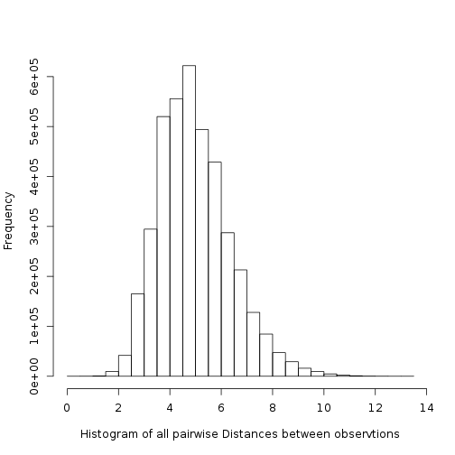

> Visualization is very important for data analytics, as it can provide a first understanding of the data.

#### Step 6. Select the clustering method to use and decide how many clusters to have

At this stage, we need to decide what type of clustering we want to use as well as what number of clusters we would like to define. As the details and differences of the two types of clustering where outside of the scope of our course, we simply decided to stick with the default setting using the “hclust”-approach (as opposed to the “k-means”). Furthermore, we choose to stick to the pre-set Eucledian distance, as this provides a non-negative and continuous distance definition, which amplifies the effects of two widely separated data points (as it is the squared distance).

In order to determine the number of clusters which we define, we used trial and error until we obtained clusters which had a clear “identity”“ terms of questionnaire answers. Eventually, we determined the number of clusters which yielded the clearest pattern within the clusters (in terms of a cluster having a mean which deviates clearly the mean of the entire population), were seven.

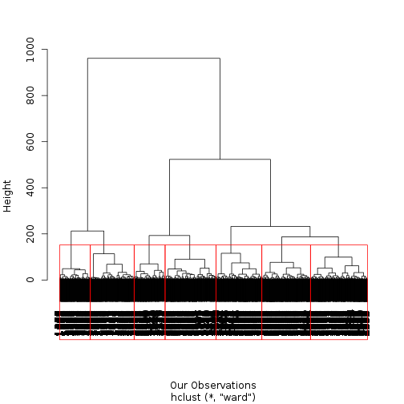

Note that we can draw as many clusters are we choose (e.g. in this case we chose 7 clusters) around the branches of the Dendrogram.

#### Step 7. Profile and interpret the clusters

After 6 rounds of iterations, we found 7 distinct customer segments. Below are the detailed profile description of the segments:

Segment 1: The Nouveau Boaters - Mostly men, not price sensitive, taking boat as a social activity, a new lifestyle experience

Segment 2: The Buffy Boaters - Mostly men, experienced boaters, knowledgeable and can perform repair, not price sensitive

Segment 3: The Wall Street financiers - Mostly men, brand and status are why they take on boats, just like with golf, country club, cars… - it's all about prestige and class

Segment 4: The Hippy Emma - These tend to be hippy younger inexperienced boaters, but if they take on boat, they prefer to repair things on their own, to be independent

Segment 5: Young Bill - The rising boaters, young, like to take on boating as a passion, but price sensitive

Segment 6: Cheap buy, preferring no frills

Segment 7: Disinterested customer segment

We can also “visualize” the segments using **snake plots** for each cluster. For example, we can plot the means of the profiling variables for each of our clusters to better visualize differences between segments. For better visualization we plot the standardized profiling variables.

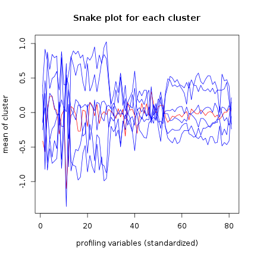

We can measure the ratios of the average for each cluster to the average of the population (e.g. avg(cluster)/avg(population)) and explore a matrix as the following one:

|  | Segment 1 | Segment 2 | Segment 3 | Segment 4 | Segment 5 | Segment 6 | Segment 7 |
| --- | --- | --- | --- | --- | --- | --- | --- |
| Q1_1_When buying a boat I do a lot of shopping around and visit multiple dealers | 0.9164 | 1.054 | 1.08 | 0.9696 | 1.079 | 0.973 | 0.9483 |
| Q1_2_When buying a boat getting the lowest price is more important than the boat brand | 0.799 | 0.8014 | 0.7102 | 1.025 | 1.323 | 1.163 | 1.098 |
| Q1_3_The brand of boat I buy says a lot about who I am | 1.021 | 0.9904 | 1.287 | 0.7611 | 1.245 | 1.012 | 0.7259 |
| Q1_4_I only consider buying a boat from a reputable brand | 1.049 | 1.059 | 1.132 | 0.9178 | 1.073 | 0.9166 | 0.8901 |
| Q1_5_I am willing to pay a premium for a brand with a reputation for high quality | 1.063 | 1.059 | 1.22 | 0.8306 | 1.129 | 0.9374 | 0.8077 |
| Q1_6_Owning a boat is a way of rewarding myself for my hard work | 1.01 | 1.017 | 1.165 | 0.9155 | 1.109 | 0.9605 | 0.8533 |
| Q1_7_Owning a boat gives me a sense of achievement | 1.009 | 0.9912 | 1.20 | 0.8719 | 1.146 | 0.9836 | 0.8376 |
| Q1_8_When buying a boat functionality is more important than style | 0.932 | 0.9944 | 0.9598 | 1.034 | 1.071 | 1.004 | 0.9852 |
| Q1_9_I see my boat as a status symbol | 0.9872 | 0.9247 | 1.298 | 0.6974 | 1.33 | 1.069 | 0.7456 |
| Q1_10_When buying a boat I rely more on expert opinion than my own e g consumer reports salespeople | 1.008 | 0.9446 | 0.9798 | 0.9312 | 1.112 | 1.02 | 1.013 |
| Q1_11_I tend to perform minor boat repairs and maintenance on my own | 0.6324 | 1.182 | 1.237 | 1.171 | 1.133 | 1.004 | 0.5461 |
| Q1_12_When it comes to boating I tend to prefer a basic boat with little to no frills | 0.8059 | 0.8644 | 0.7203 | 1.141 | 1.20 | 1.119 | 1.043 |
| Q1_13_When buying a boat I tend to buy the latest and greatest | 1.029 | 0.9864 | 1.258 | 0.7247 | 1.264 | 1.018 | 0.7691 |
| Q1_14_When buying accessories for my boat I tend to buy the latest and greatest | 1.017 | 0.9986 | 1.268 | 0.7967 | 1.205 | 0.9917 | 0.7708 |
| Q1_15_I am serious about the technology on my boat | 0.9935 | 1.046 | 1.208 | 0.8687 | 1.132 | 0.9737 | 0.8082 |
| Q1_16_People tend to come to me for advice about boating | 0.9095 | 1.051 | 1.30 | 0.813 | 1.232 | 1.036 | 0.67 |
| Q1_17_I consider myself more knowledgeable about boating than the rest of my boating peers | 0.9151 | 1.022 | 1.249 | 0.8549 | 1.224 | 1.033 | 0.7044 |
| Q1_18_Boating gives me a feeling of adventure | 1.006 | 1.015 | 1.151 | 0.9538 | 1.081 | 0.9383 | 0.8924 |
| Q1_19_Boating allows me to experience nature | 1.004 | 1.02 | 1.109 | 0.9753 | 1.054 | 0.9464 | 0.9179 |
| Q1_20_When not on my boat I often find myself doing boating related activities | 0.9372 | 1.024 | 1.245 | 0.8183 | 1.219 | 1.036 | 0.7353 |
| Q1_21_Boating helps me escape from everyday life and relax | 1.026 | 1.024 | 1.13 | 0.9711 | 1.053 | 0.9313 | 0.8939 |
| Q1_22_Boating helps me stay active | 1.019 | 1.016 | 1.151 | 0.9377 | 1.074 | 0.9671 | 0.8558 |
| Q1_23_Boating allows me to excel in the sports that I am passionate about e g fishing racing water sports | 0.9855 | 1.007 | 1.273 | 0.7985 | 1.158 | 1.053 | 0.7487 |
| Q1_24_Boating gives me an outlet to socialize with family and or friends | 1.022 | 1.027 | 1.116 | 0.9406 | 1.055 | 0.9525 | 0.9159 |
| Q1_25_Being in charge of my boat is very important to me | 0.9611 | 1.031 | 1.201 | 0.9108 | 1.121 | 0.9929 | 0.7988 |
| Q1_26_Having a powerful boat is what is most important to me | 0.9897 | 0.9753 | 1.252 | 0.7326 | 1.263 | 1.054 | 0.7723 |
| Q1_27_Boating is the number one thing I do with my spare time | 1.004 | 0.9591 | 1.314 | 0.7439 | 1.279 | 1.056 | 0.6706 |
| Q1_28_Boating is my true passion in life | 0.9912 | 1.024 | 1.305 | 0.74 | 1.232 | 1.031 | 0.7166 |
| Q1_29_Boating is one of many things I do in my spare time | 1.009 | 1.019 | 1.091 | 0.9685 | 1.076 | 0.9606 | 0.8829 |
| Q2_How many powerboats do you currently own | 1.011 | 1.047 | 1.106 | 1.00 | 1.06 | 0.9414 | 0.8273 |

[output cut: 51 more lines]

#### Step 8. Assess the robustness of our clusters

We will skip this step for this exercise. However in practice this is a very important step.

## Intepretation, Decisions and Conclusion

The company should look further into segment 1, 2, 3 and 5 as target customers and tailor their product positioning to each segment. While segment 5 is price sensitive, having boat as a passion will potentially carry on when they become older and have more income. Next steps would be to assess each segment's market size and competitiveness.